# Final Project

Ramachandran Chandrasekara, DiJavante Albert, Tigist Gebeyehu

12/3/2019

# Analytics Problem

Can you predict the success or failure of a campaign on Kickstarter? Using variables like country, category, goal amount, and amount of backers, is there a predictive model that can show the chances of success and failure?

# Business Purpose

Kickstarter is a crowdsourcing site where people can raise money from potential donors in order to fund their projects. Campaigners must set a goal amount at the beginning of their campaign, and then they often give something to donors at certain levels of donations in order to incentivize more donations. Success varies on the different projects dependent upon the goal amount asked for, when the project launched, etc.. If a goal is successful, Kickstarter collects a 5% fee from the amount raised. Kickstarter is highly incentivized to ensure the success of each of the projects launched on their site so that they can collect fees from those projects. By building a predictive model to show the correlation of the different variables to the success or failure of a project, Kickstarter can give valuable insight to their campaigners in order to improve their chances of having a successful campaign.

# Dataset

The dataset we used was from https://www.kaggle.com/kemical/kickstarter-projects/downloads/kickstarter-projects.zip/7 that was provided to us in class. In it are over 300k rows of data representing individual campaigns from Kickstarter. There were a number of variables available within the dataset, including Category, which fed into high Main Category that we used instead due to the number of sub-categories available. Additionally, we decided that we would use the number of backers, the country of origin, goal amount, category and length of the campaign as independent variables. Below we have charts showing the number of campaigns that were in each category, with Film and Video coming in as the highest, as well as the charts for the US vs. non-US, length distribution, and status rate.

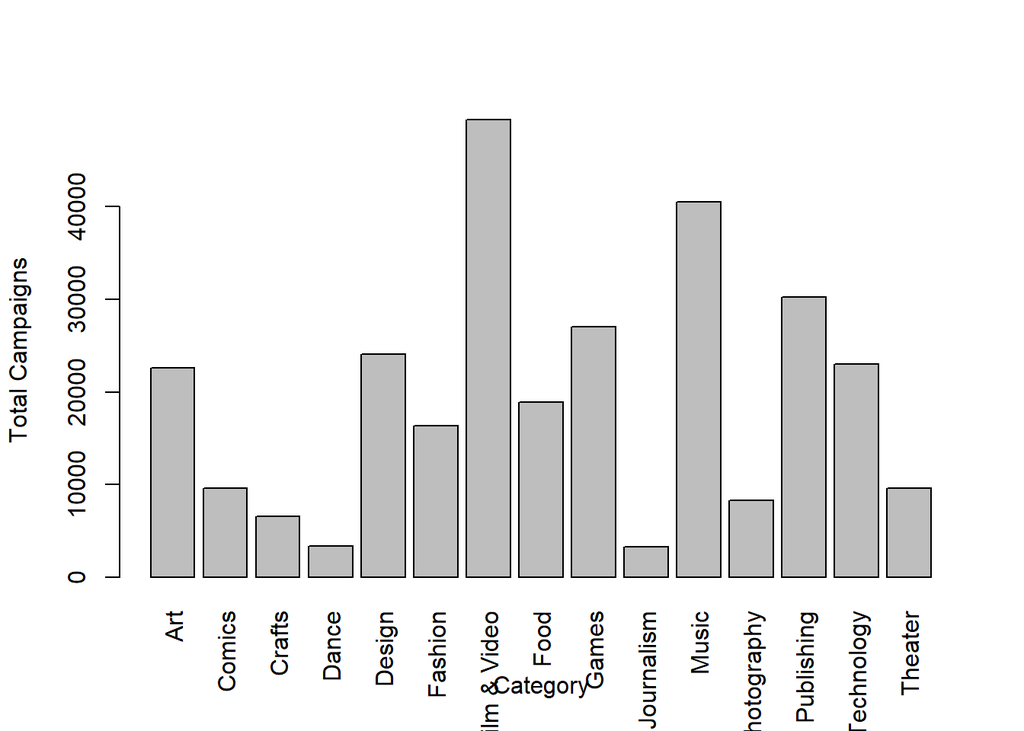

```r
library(readr)
Kickstarter3 <-read.csv("Kickstarter3GLM.csv", header = TRUE, sep = ",")
attach(Kickstarter3)
plot(Kickstarter3$Category, xlab ="Category", ylab ="Total Campaigns", las=3)
```

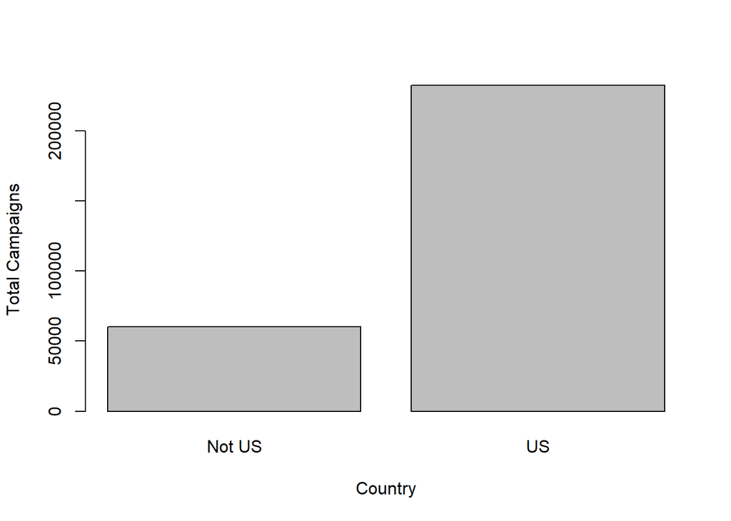

```r
plot(Kickstarter3$Country, xlab = "Country", ylab = "Total Campaigns")
```

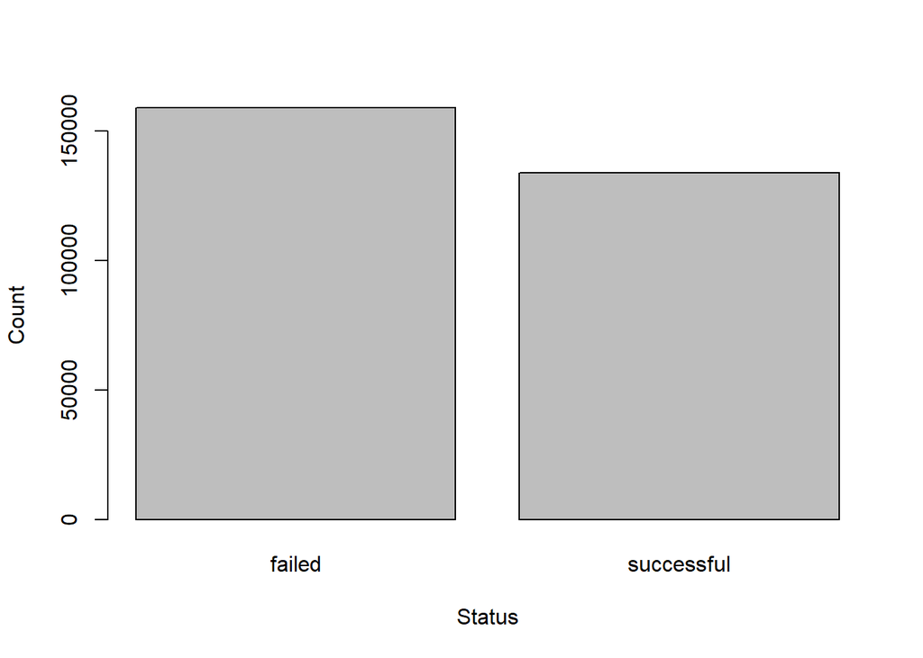

```r
plot(Kickstarter3$Status, xlab = "Status", ylab = "Count")
```

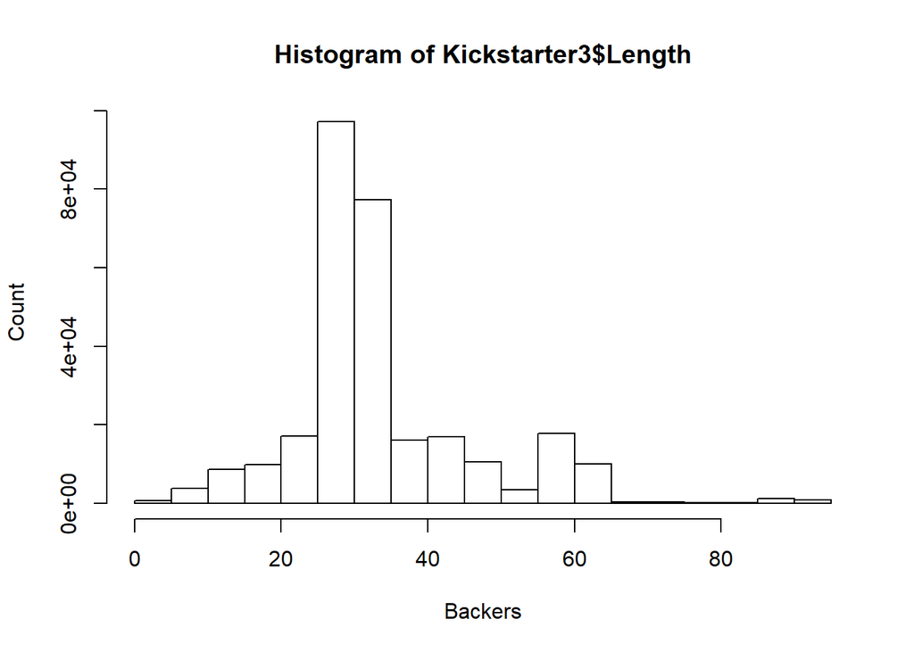

```r
hist(Kickstarter3$Length, xlab = "Backers", ylab = "Count")
```

```r
message=FALSE
```

# Models

**Binomial Logistic Model**

```r
set.seed(10)
train=sample(1:nrow(Kickstarter3), 0.8*nrow(Kickstarter3))
glm.log.kick <- glm(Status~., data = Kickstarter3[train,],family = binomial(link = "logit"))
message=FALSE
summary(glm.log.kick)
```

```
##
## Call:
## glm(formula = Status ~ ., family = binomial(link = "logit"),
##     data = Kickstarter3[train, ])
##
## Deviance Residuals:
##     Min       1Q   Median       3Q      Max
## -8.4904  -0.5662  -0.0014   0.4507   8.4904
##
## Coefficients:
##                        Estimate Std. Error  z value Pr(>|z|)
## (Intercept)          -5.838e-02  2.722e-02   -2.145 0.031992 *
## CategoryComics       -5.651e-01  3.988e-02  -14.171  < 2e-16 ***
## CategoryCrafts       -7.114e-01  4.181e-02  -17.014  < 2e-16 ***
## CategoryDance         6.961e-01  5.468e-02   12.731  < 2e-16 ***
## CategoryDesign       -7.114e-01  3.246e-02  -21.918  < 2e-16 ***
## CategoryFashion      -5.824e-01  3.226e-02  -18.053  < 2e-16 ***
## CategoryFilm & Video  2.322e-01  2.371e-02    9.794  < 2e-16 ***
## CategoryFood         -4.566e-01  3.302e-02  -13.828  < 2e-16 ***
## CategoryGames        -1.582e+00  3.423e-02  -46.203  < 2e-16 ***
## CategoryJournalism   -5.447e-01  6.095e-02   -8.936  < 2e-16 ***
## CategoryMusic         1.591e-01  2.413e-02    6.593 4.31e-11 ***
## CategoryPhotography  -3.829e-01  3.783e-02  -10.121  < 2e-16 ***
## CategoryPublishing   -5.528e-01  2.642e-02  -20.924  < 2e-16 ***
## CategoryTechnology   -5.880e-01  3.591e-02  -16.373  < 2e-16 ***
## CategoryTheater       6.866e-01  3.650e-02   18.812  < 2e-16 ***
## Length               -1.364e-02  4.887e-04  -27.915  < 2e-16 ***
## Backers               5.035e-02  2.602e-04  193.486  < 2e-16 ***
## CountryUS             5.633e-02  1.570e-02    3.589 0.000332 ***
## GoalAmount           -2.176e-04  1.379e-06 -157.751  < 2e-16 ***
## ---
## Signif. codes:  0 '***' 0.001 '**' 0.01 '*' 0.05 '.' 0.1 ' ' 1
##
## (Dispersion parameter for binomial family taken to be 1)
##
##     Null deviance: 323048  on 234261  degrees of freedom
## Residual deviance: 155616  on 234243  degrees of freedom
## AIC: 155654
##
## Number of Fisher Scoring iterations: 12
```

```r
log.odds <- coef(glm.log.kick)
log.odds
```

```
##          (Intercept)       CategoryComics       CategoryCrafts
##        -0.0583777245        -0.5650945223        -0.7113870332
##        CategoryDance       CategoryDesign      CategoryFashion
##         0.6961032476        -0.7113688311        -0.5823922695
## CategoryFilm & Video         CategoryFood        CategoryGames
##         0.2321723879        -0.4566252698        -1.5816745850
##   CategoryJournalism        CategoryMusic  CategoryPhotography
##        -0.5446661498         0.1591200708        -0.3829274904
##   CategoryPublishing   CategoryTechnology      CategoryTheater
##        -0.5527930318        -0.5879724202         0.6865943879
##               Length              Backers            CountryUS
##        -0.0136428758         0.0503519197         0.0563290505
##           GoalAmount
##        -0.0002175841
```

```r
odds <- exp(coef(glm.log.kick))
odds
```

```
##          (Intercept)       CategoryComics       CategoryCrafts
##            0.9432936            0.5683064            0.4909627
##        CategoryDance       CategoryDesign      CategoryFashion
##            2.0059209            0.4909717            0.5585605
## CategoryFilm & Video         CategoryFood        CategoryGames
##            1.2613371            0.6334177            0.2056305
##   CategoryJournalism        CategoryMusic  CategoryPhotography
##            0.5800354            1.1724787            0.6818623
##   CategoryPublishing   CategoryTechnology      CategoryTheater
##            0.5753406            0.5554524            1.9869373
##               Length              Backers            CountryUS
##            0.9864498            1.0516411            1.0579457
##           GoalAmount
##            0.9997824
```

```r
prob <- odds/(1+odds)
prob
```

```
##          (Intercept)       CategoryComics       CategoryCrafts
##            0.4854097            0.3623695            0.3292924
##        CategoryDance       CategoryDesign      CategoryFashion
##            0.6673232            0.3292964            0.3583823
## CategoryFilm & Video         CategoryFood        CategoryGames
##            0.5577838            0.3877867            0.1705585
##   CategoryJournalism        CategoryMusic  CategoryPhotography
##            0.3671028            0.5396963            0.4054210
##   CategoryPublishing   CategoryTechnology      CategoryTheater
##            0.3652166            0.3571002            0.6652089
##               Length              Backers            CountryUS
##            0.4965893            0.5125853            0.5140785
##           GoalAmount
##            0.4999456
```

```r
cbind("Log-Odds"=log.odds, "Odds"=odds, "Probabilities"=prob)
```

```
##                           Log-Odds      Odds Probabilities
## (Intercept)          -0.0583777245 0.9432936     0.4854097
## CategoryComics       -0.5650945223 0.5683064     0.3623695
## CategoryCrafts       -0.7113870332 0.4909627     0.3292924
## CategoryDance         0.6961032476 2.0059209     0.6673232
## CategoryDesign       -0.7113688311 0.4909717     0.3292964
## CategoryFashion      -0.5823922695 0.5585605     0.3583823
## CategoryFilm & Video  0.2321723879 1.2613371     0.5577838
## CategoryFood         -0.4566252698 0.6334177     0.3877867
## CategoryGames        -1.5816745850 0.2056305     0.1705585
## CategoryJournalism   -0.5446661498 0.5800354     0.3671028
## CategoryMusic         0.1591200708 1.1724787     0.5396963
## CategoryPhotography  -0.3829274904 0.6818623     0.4054210
## CategoryPublishing   -0.5527930318 0.5753406     0.3652166
## CategoryTechnology   -0.5879724202 0.5554524     0.3571002
## CategoryTheater       0.6865943879 1.9869373     0.6652089
## Length               -0.0136428758 0.9864498     0.4965893
## Backers               0.0503519197 1.0516411     0.5125853
## CountryUS             0.0563290505 1.0579457     0.5140785
## GoalAmount           -0.0002175841 0.9997824     0.4999456
```

```r
preds.probs <- predict(glm.log.kick, Kickstarter3[-train,], type = "response")
pred.hi.kick <- ifelse(preds.probs>0.5, 1, 0)
pred.table=table(pred.hi.kick, data=Kickstarter3$Status[-train])
pred.table
```

```
##             data
## pred.hi.kick failed successful
##            0  29743       3763
##            1   2106      22954
```

```r
TruN=pred.table[1,1]
TruP=pred.table[2,2]
FalN=pred.table[1,2]
FalP=pred.table[2,1]
TotN=pred.table[1,1] + pred.table[2,1]
TotP=pred.table[1,2] + pred.table[2,2]
Tot=TotN+TotP
Accuracy.Rate.log=(TruN+TruP)/Tot
Accuracy.Rate.log
```

```
## [1] 0.8997883
```

```r
Error.Rate=(FalN+FalP)/Tot
Error.Rate
```

```
## [1] 0.1002117
```

```r
Sensitivity=TruP/TotP
Sensitivity
```

```
## [1] 0.8591533
```

```r
Specificity=TruN/TotN
Specificity
```

```
## [1] 0.9338755
```

```r
message=FALSE
```

**Linear Discrimanant Analysis**

Linear Discriminant Analysis (LDA) is a method used to find linear combinations of features that characterizes or separates two or more classes of objects. LDA is also closely related to analysis of variance (ANOVA) where it attempts to express one dependant variable as a linear combination of other measurements. In this case, we are given a classification model where we are trying to predict the success/failure status of the Kickstarter data using the LDA model.

```r
set.seed(10)
train=sample(1:nrow(Kickstarter3), 0.8*nrow(Kickstarter3))
require(MASS)
lda.log.kick <- lda(Status~., data = Kickstarter3[train,])
log.odds <- coef(lda.log.kick)
log.odds
```

```
##                                LD1
## CategoryComics        7.577609e-01
## CategoryCrafts       -1.446844e+00
## CategoryDance         1.375512e+00
## CategoryDesign       -5.301193e-01
## CategoryFashion      -1.233621e+00
## CategoryFilm & Video -1.590381e-01
## CategoryFood         -1.345060e+00
## CategoryGames        -4.810142e-01
## CategoryJournalism   -1.356955e+00
## CategoryMusic         7.188238e-01
## CategoryPhotography  -7.317585e-01
## CategoryPublishing   -7.440227e-01
## CategoryTechnology   -1.621400e+00
## CategoryTheater       1.312301e+00
## Length               -3.882529e-02
## Backers               4.235314e-04
## CountryUS             3.004279e-01
## GoalAmount           -7.468541e-08
```

```r
odds <- exp(coef(lda.log.kick))
odds
```

```
##                            LD1
## CategoryComics       2.1334938
## CategoryCrafts       0.2353118
## CategoryDance        3.9571033
## CategoryDesign       0.5885348
## CategoryFashion      0.2912362
## CategoryFilm & Video 0.8529639
## CategoryFood         0.2605241
## CategoryGames        0.6181562
## CategoryJournalism   0.2574434
## CategoryMusic        2.0520182
## CategoryPhotography  0.4810623
## CategoryPublishing   0.4751985
## CategoryTechnology   0.1976219
## CategoryTheater      3.7147125
## Length               0.9619188
## Backers              1.0004236
## CountryUS            1.3504365
## GoalAmount           0.9999999
```

```r
prob <- odds/(1+odds)
prob
```

```
##                            LD1
## CategoryComics       0.6808674
## CategoryCrafts       0.1904878
## CategoryDance        0.7982693
## CategoryDesign       0.3704891
## CategoryFashion      0.2255484
## CategoryFilm & Video 0.4603241
## CategoryFood         0.2066792
## CategoryGames        0.3820127
## CategoryJournalism   0.2047356
## CategoryMusic        0.6723480
## CategoryPhotography  0.3248090
## CategoryPublishing   0.3221251
## CategoryTechnology   0.1650119
## CategoryTheater      0.7878980
## Length               0.4902949
## Backers              0.5001059
## CountryUS            0.5745471
## GoalAmount           0.5000000
```

```r
cbind("Log-Odds"=log.odds, "Odds"=odds, "Probabilities"=prob)
```

```
##                                LD1       LD1       LD1
## CategoryComics        7.577609e-01 2.1334938 0.6808674
## CategoryCrafts       -1.446844e+00 0.2353118 0.1904878
## CategoryDance         1.375512e+00 3.9571033 0.7982693
## CategoryDesign       -5.301193e-01 0.5885348 0.3704891
## CategoryFashion      -1.233621e+00 0.2912362 0.2255484
## CategoryFilm & Video -1.590381e-01 0.8529639 0.4603241
## CategoryFood         -1.345060e+00 0.2605241 0.2066792
## CategoryGames        -4.810142e-01 0.6181562 0.3820127
## CategoryJournalism   -1.356955e+00 0.2574434 0.2047356
## CategoryMusic         7.188238e-01 2.0520182 0.6723480
## CategoryPhotography  -7.317585e-01 0.4810623 0.3248090
## CategoryPublishing   -7.440227e-01 0.4751985 0.3221251
## CategoryTechnology   -1.621400e+00 0.1976219 0.1650119
## CategoryTheater       1.312301e+00 3.7147125 0.7878980
## Length               -3.882529e-02 0.9619188 0.4902949
## Backers               4.235314e-04 1.0004236 0.5001059
## CountryUS             3.004279e-01 1.3504365 0.5745471
## GoalAmount           -7.468541e-08 0.9999999 0.5000000
```

```r
preds.probs <- predict(lda.log.kick, Kickstarter3[-train,], type = "response")
pred.table=table(preds.probs$class, data=Kickstarter3$Status[-train])
pred.table
```

```
##             data
##              failed successful
##   failed      23481      13492
##   successful   8368      13225
```

```r
TruN.lda=pred.table[1,1]
TruP.lda=pred.table[2,2]
FalN.lda=pred.table[1,2]
FalP.lda=pred.table[2,1]
TotNlda=pred.table[1,1] + pred.table[2,1]
TotPlda=pred.table[1,2] + pred.table[2,2]
Tot.lda=TotNlda+TotPlda
Accuracy.Rate.lda=(TruN.lda+TruP.lda)/Tot.lda
Accuracy.Rate.lda
```

```
## [1] 0.6267459
```

```r
Error.Rate.lda=(FalN.lda+FalP.lda)/Tot.lda
Error.Rate.lda
```

```
## [1] 0.3732541
```

```r
Sensitivity.lda=TruP.lda/TotPlda
Sensitivity.lda
```

```
## [1] 0.4950032
```

```r
Specificity.lda=TruN.lda/TotNlda
Specificity.lda
```

```
## [1] 0.7372602
```

```r
message=FALSE
```

**Classification Tree**

```r
require(class)
library(tree)
tree.kick <- tree(Status~., Kickstarter3)
summary(tree.kick)
```

```
##
## Classification tree:
## tree(formula = Status ~ ., data = Kickstarter3)
## Variables actually used in tree construction:
## [1] "Backers"    "GoalAmount"
## Number of terminal nodes:  8
## Residual mean deviance:  0.5753 = 168500 / 292800
## Misclassification error rate: 0.111 = 32509 / 292828
```

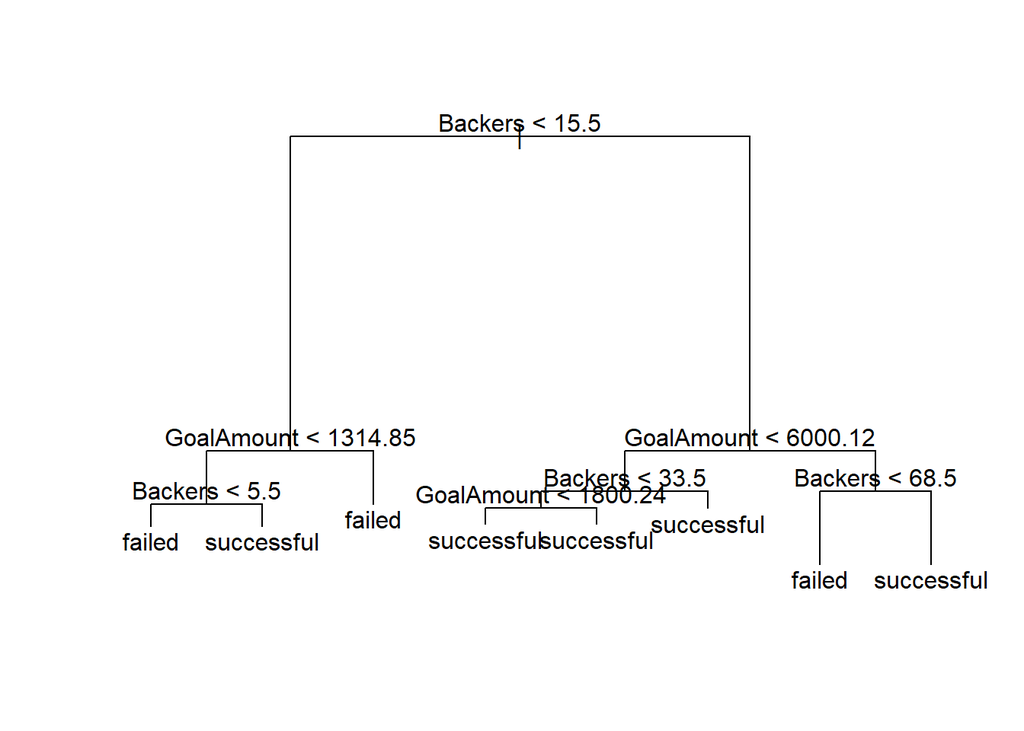

```r
plot(tree.kick)
text(tree.kick, pretty = 0)
```

```r
cv.kick=cv.tree(tree.kick, FUN=prune.misclass)
names(cv.kick)
```

```
## [1] "size"   "dev"    "k"      "method"
```

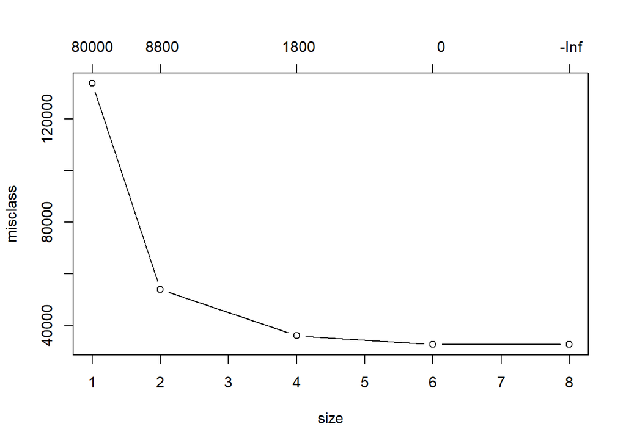

```r
plot(cv.kick, type="b")
```

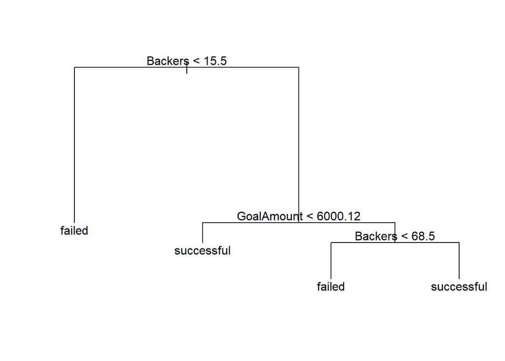

```r
prune.kick=prune.misclass(tree.kick,best=4)
plot(prune.kick)
text(prune.kick, pretty=0)
```

```r
train=sample(1:nrow(Kickstarter3), 0.8*nrow(Kickstarter3))
kick.fit.tree = tree(Status~., data=Kickstarter3[train,])
summary(kick.fit.tree)
```

```
##
## Classification tree:
## tree(formula = Status ~ ., data = Kickstarter3[train, ])
## Variables actually used in tree construction:
## [1] "Backers"    "GoalAmount"
## Number of terminal nodes:  9
## Residual mean deviance:  0.5652 = 132400 / 234300
## Misclassification error rate: 0.1101 = 25791 / 234262
```

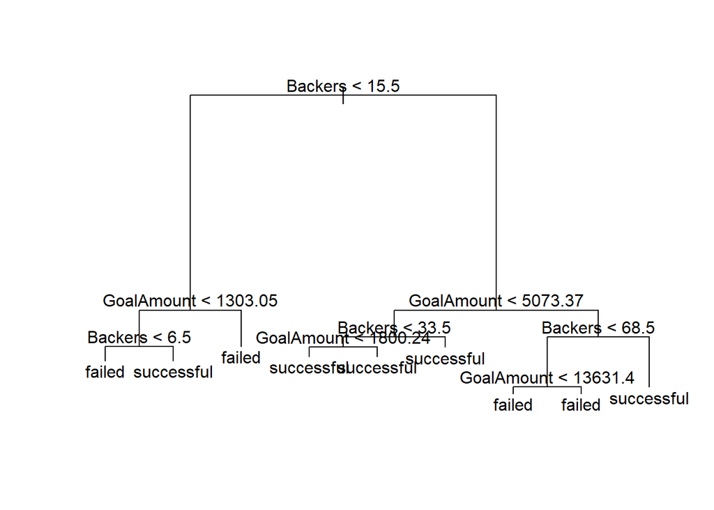

```r
plot(kick.fit.tree)
text(kick.fit.tree, pretty=0)
```

```r
kick.test = Kickstarter3[-train,]
kick.tree.pred.class=predict(kick.fit.tree, kick.test, type="class")
kick.tree.pred.prob=predict(kick.fit.tree, kick.test)
kick.tree.confmat=table(kick.tree.pred.class, kick.test$Status)
kick.tree.confmat
```

```
##
## kick.tree.pred.class failed successful
##           failed      27580       2144
##           successful   4234      24608
```

```r
TruN.kick=kick.tree.confmat[1,1]
TruP.kick=kick.tree.confmat[2,2]
FalN.kick=kick.tree.confmat[1,2]
FalP.kick=kick.tree.confmat[2,1]
TotNkick=kick.tree.confmat[1,1] + kick.tree.confmat[2,1]
TotPkick=kick.tree.confmat[1,2] + kick.tree.confmat[2,2]
Totkick=TotNkick+TotPkick # Total
Accuracy.Rate.kick=(TruN.kick+TruP.kick)/Tot
Accuracy.Rate.kick
```

```
## [1] 0.8910972
```

```r
Error.Rate.kick=(FalN.kick+FalP.kick)/Totkick
Error.Rate.kick
```

```
## [1] 0.1089028
```

```r
Sensitivity.kick=TruP.kick/TotPkick
Sensitivity.kick
```

```
## [1] 0.9198565
```

```r
Specificity.kick=TruN.kick/TotNkick
Specificity.kick
```

```
## [1] 0.8669139
```

```r
message=FALSE
```

# Concluding Thoughts

Based on the error rate, sensitivity and specificity, it is clear that the LDA model is not the best model to go with for Kickstarter. When comparing the binomial logistic model to the classification tree, it appears they both can be used. The classification tree has a low error rate and a splits between the sensitivity and specificity with the logistic model, but given the tree only used the backers and goal amount from the variables, it does not give Kickstarter a good amount of data to work from in order to determine how to best improve the success rate of differing campaigns. The logistic model has the lowest error rate, highest specificity, and is comparable in sensitivity to the classification tree. Therefore, the logistic model should be used as the model for Kickstarter.

The lessons learned from this project are that when doing modelling, it is important to have trial and error with R especially. Also, there will be many iterations of the models as you try to get the model to fit best without overfitting.

**Accuracy Rate**

```r
cbind("Logistic"=Accuracy.Rate.log, "LDA"=Accuracy.Rate.lda, "Tree"=Accuracy.Rate.kick)
```

```
##       Logistic       LDA      Tree
## [1,] 0.8997883 0.6267459 0.8910972
```

```r
message=FALSE
```

**Error Rate**

```r
cbind("Logistic"=Error.Rate, "LDA"=Error.Rate.lda, "Tree"=Error.Rate.kick)
```

```
##       Logistic       LDA      Tree
## [1,] 0.1002117 0.3732541 0.1089028
```

```r
message=FALSE
```

**Sensitivity**

```r
cbind("Logistic"=Sensitivity, "LDA"=Sensitivity.lda, "Tree"=Sensitivity.kick)
```

```
##       Logistic       LDA      Tree
## [1,] 0.8591533 0.4950032 0.9198565
```

```r
message=FALSE
```

**Specificity**

```r
cbind("Logistic"=Specificity, "LDA"=Specificity.lda, "Tree"=Specificity.kick)
```

```
##       Logistic       LDA      Tree
## [1,] 0.9338755 0.7372602 0.8669139
```

```r
message=FALSE
```